# markdown

minah

2019 11 21

### 분석사례 (p.78)

1. 자료 파일 읽기

```r
library(readxl)
chemical <-read_excel("D:\\Workspace\\RegressionModel\\RegressionModel_Assignment\\p78.xlsx",1)
head(chemical)
```

```
## # A tibble: 6 x 4
##      NO SPEED  TEMP  LOSS
##   <dbl> <dbl> <dbl> <dbl>
## 1     1    70    20    15
## 2     2    80    27    42
## 3     3    75    25    37
## 4     4    62    24    28
## 5     5    65    23    20
## 6     6    58    18    14
```

head 함수를 통하여 데이터 값의 처음 6줄을 보여준다.

2. 기술 통계량 및 상관계수 보기

```r
summary(chemical[,-1])
```

```
##      SPEED           TEMP            LOSS
##  Min.   :50.0   Min.   :17.00   Min.   : 8.00
##  1st Qu.:57.5   1st Qu.:19.50   1st Qu.:13.75
##  Median :61.0   Median :20.50   Median :16.50
##  Mean   :63.0   Mean   :21.50   Mean   :20.25
##  3rd Qu.:70.5   3rd Qu.:24.25   3rd Qu.:24.25
##  Max.   :80.0   Max.   :27.00   Max.   :42.00
```

```r
cor(chemical[,-1])
```

```
##           SPEED      TEMP      LOSS
## SPEED 1.0000000 0.8023847 0.8548423
## TEMP  0.8023847 1.0000000 0.8953498
## LOSS  0.8548423 0.8953498 1.0000000
```

cor 명령을 통해 독립변수들(속도, 온도)과 종속변수(손실량) 간의 상관관계가 각각 0.8548423, 0.8953498로 높음을 알 수 있다.

3. 회귀모형 적합하기

```r
chemical.lm=lm(LOSS~SPEED+TEMP, data=chemical)
summary(chemical.lm)
```

```
##
## Call:
## lm(formula = LOSS ~ SPEED + TEMP, data = chemical)
##
## Residuals:
##     Min      1Q  Median      3Q     Max
## -7.7699 -2.4093  0.2795  3.4019  4.9654
##
## Coefficients:
##             Estimate Std. Error t value Pr(>|t|)
## (Intercept) -47.6243     9.4580  -5.035 0.000704 ***
## SPEED         0.4216     0.2350   1.794 0.106360
## TEMP          1.9217     0.6977   2.754 0.022316 *
## ---
## Signif. codes:  0 '***' 0.001 '**' 0.01 '*' 0.05 '.' 0.1 ' ' 1
##
## Residual standard error: 4.465 on 9 degrees of freedom
## Multiple R-squared:  0.8539, Adjusted R-squared:  0.8214
## F-statistic:  26.3 on 2 and 9 DF,  p-value: 0.0001741
```

summary 함수를 통하여 추정된 회귀방정식은 y^=-47.6243 + 0.4216*speed + 1.9217*temp 이다.

결정계수 R-square = 0.8539로서, 중회귀모형이 종속변수 loss의 총변동을 85.4%정도 설명하고 있음을 나타낸다.

표준오차 root MSE=4.465 로서, σ의 추정치가 4.465임을 알 수 있다.

speed에 대한 유의확률 p-값은 0.106360으로 유의수준 0.05에서 loss에 대한 설명력이 약하다고 할 수 있으며,

temp에 대한 유의확률 p-값은 0.022316으로 유의수준 0.05의 범위내에 있으므로, loss에 대한 설명력이 높다고 할 수 있다.

```r
par("mar")
```

```
## [1] 5.1 4.1 4.1 2.1
```

```r
par(mar=c(1,1,1,1))
library(car)
```

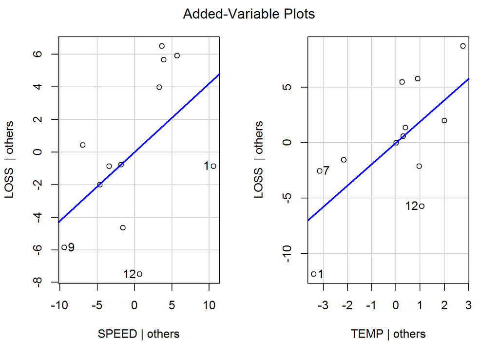

```r
library(carData)
avPlots(chemical.lm)
```

speed에 대한 추가변수그림을 보면 선형성이 낮으므로, speed 변수는 회귀모형에서 유의성이 떨어진다고 볼 수 있으며, temp에 대한 추가변수 그림은 선형성이 높으므로 temp 변수의 유의성은 높음을 알 수 있다.

4. 분산분석표

[output not shown]

summary함수에서 본 F-statistics=26.3에 대한 p-value=0.0001741 로 매우 작으므로, 본 중회귀모형이 매우 유의함을 알 수 있다. 또한 오차분산의 추정치 MSE=19.94임을 알 수 있다.

5. 잔차산점도 그리기

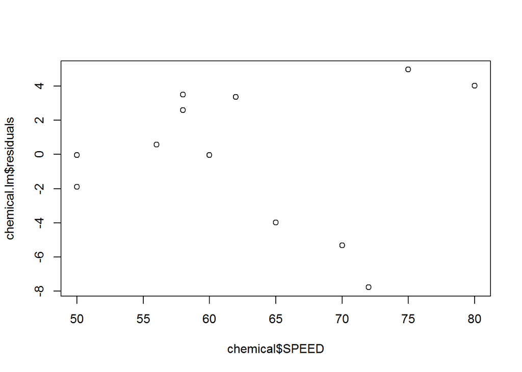

```
## integer(0)
```

```r
plot(chemical$SPEED, chemical.lm$residuals)
identify(chemical$SPEED, chemical.lm$residuals)
```

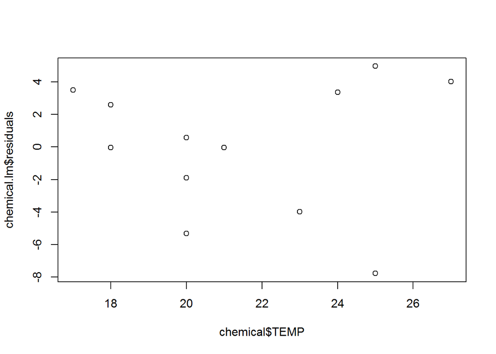

```
## integer(0)
```

```r
plot(chemical$TEMP, chemical.lm$residuals)
identify(chemical$TEMP, chemical.lm$residuals)
```

잔차산점도를 보면 speed, temp 변수 모두 12번째 데이터가 떨어져있어 특이점으로 보이며, 그를 제외하면 아래로 볼록한 2차곡선의 모양을 갖는 것처럼 보인다.

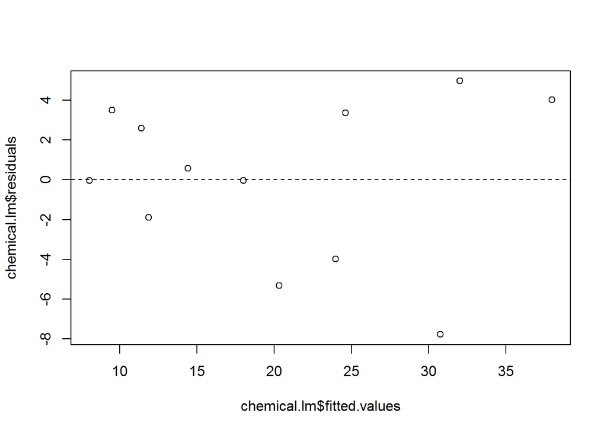

```
## integer(0)
```

```r
plot(chemical.lm$fitted.values, chemical.lm$residuals)
abline(h=0, lty=2)
identify(chemical.lm$fitted.values, chemical.lm$residuals)
```

Y(loss)추정값과 잔차의 산점도를 보면 12번째 데이터를 제외하면 어떤 뚜렷한 현상은 나타나지 않고 있다. 12번째케이스에 대한 조사를 거쳐 특이점으로 판명되면 이 케이스를 제외하고 분석이 필요할 것으로 보인다.